# Text Preparation

Author

Heather Copley, Jarret Glass, Andras Paul

```r
library(tidyverse)
library(caret)
library(quanteda)
library(here)
library(reticulate)
library(janitor)
library(irlba)
use_condaenv('r-gensim', required = TRUE)
```

# Text Preparation: PubMedBERT vs TF-IDF vs Doc2Vec

## 1: Set up for 5-Fold Cross Validation

Create stratified 5-fold CV splits using `createFolds()` from the `caret` package, stratifying on `outcome` to ensure each fold has approximately the same proportion of positive cases. The `folds` list is saved as an `.rds` file so the same fold assignments can be reused in `model_comparison.qmd`.

```r
# Load cleaned abstracts and labels; assign a row ID to each record
# str_squish() collapses embedded \n, \r\n, \t to single spaces so that
# the text field is single-line and safe for CSV/Python parsing
abstracts <- readRDS(here('02_data_prep', 'cleaned_input.rds')) %>%
    mutate(outcome = if_else(Outcome == 'Selected for Screening', 1, 0)) %>%
    rowid_to_column('id') %>%
    select(id, title, abstract, outcome) %>%
    unite(col = 'text', c(title, abstract), sep = ' ') %>%
    mutate(text = str_squish(text)) %>%
    arrange(id)

# Set seed for reproducibility
set.seed(42)

# Create stratified 5-fold CV splits
# folds[[k]] contains the row indices (= id values) for the test set of fold k
folds <- createFolds(abstracts$outcome, k = 5, list = TRUE, returnTrain = FALSE)

# Check stratification across folds
map_dfr(seq_along(folds), ~ tibble(
  fold     = .x,
  n        = length(folds[[.x]]),
  pos_rate = mean(abstracts$outcome[folds[[.x]]])
))
```

| fold | n | pos_rate |
| --- | --- | --- |
| 1 | 3327 | 0.06702735 |
| 2 | 3326 | 0.06313891 |
| 3 | 3326 | 0.05802766 |
| 4 | 3327 | 0.06762849 |
| 5 | 3327 | 0.07484220 |

```r
# Save folds object for use in model_comparison.qmd
saveRDS(folds, here('04_output', 'cv_folds.rds'))

# Save abstracts for Python embedding generation
write_csv(abstracts, here('04_output', 'abstracts.csv'))
```

# Text Pre-processing Methods

## Method 1: PubMedBERT

PubMedBERT is a transformer-based language model pre-trained on biomedical literature that generates dense, context-sensitive document embeddings. Unlike TF-IDF and Doc2Vec, the same word can receive different representations depending on its surrounding context. Because the model is pre-trained, it brings prior knowledge of biomedical language to the task without needing to learn from the study corpus.

Embeddings are generated in Python using the pre-trained `NeuML/pubmedbert-base-embeddings` model via the `sentence-transformers` library. No text preprocessing is applied – the pre-trained model handles this internally. Since the model is pre-trained, embeddings are fold-independent and all records are encoded at once using a batch size of 64. Fold awareness is handled in R via `cv_folds.rds`. Each record is represented as a 768-dimensional dense vector.

Run in Google Colab with GPU runtime for faster embedding generation.

```python
import pandas as pd
from sentence_transformers import SentenceTransformer

# Load abstracts (id, text, recd_screen)
df = pd.read_csv('abstracts.csv')

# Encode all records at once
model = SentenceTransformer('NeuML/pubmedbert-base-embeddings')
embeddings = model.encode(df['text'].tolist(), batch_size=64, show_progress_bar=True)

emb_df = pd.DataFrame(embeddings)
emb_df.insert(0, 'index', df['index'].values)
emb_df.insert(1, 'outcome', df['outcome'].values)

emb_df.to_csv('pubmedbert_embeddings.csv', index=False)
print(f"Final embeddings shape: {emb_df.shape}")
```

### Load PubMedBERT embeddings into R

```r
# Read back the full embeddings matrix with label column
pubmedbert <- read_csv(here('04_output', 'pubmedbert_embeddings.csv')) %>%
    clean_names()

saveRDS(pubmedbert, file = here('04_output','pubmedbert_embeddings.rds'))
```

## Method 2: TF-IDF + LSA

TF-IDF (Term Frequency-Inverse Document Frequncy) is a numerical text representation that weights each word by how frequently it appears in a document relative to how commonly it appears across all documents. Words that are distinctive to a particular document receive higher weights; words that appear in nearly every document receive lower weights. The output is a sparse matrix with one row per document and one column per term. Each value in the matrix represents:

$$\text{TF-IDF} = \text{word count in document} \times \log_{10}\left(\frac{n_{\text{documents}}}{n_{\text{documents with term}}}\right)$$

TF-IDF features are computed in R using the `quanteda` package. To prevent data leakage, both the vocabulary and IDF weights are learned from the training fold only. `dfm_match()` aligns the test fold feature set to the training vocabulary, and `dfm_weight()` applies training-fold IDF weights to the test fold matrix. Test-fold feature matrices are assembled into a single full-dataset matrix after the fold loop.

Preprocessing steps:

- Tokenization
- Lowercase
- Remove punctuation, numbers, symbols (dashes kept, emdashes removed)
- Remove stopwords (Snowball English list)
- Stem words (Porter algorithm)

```r
# TF-IDF preprocessing function

preprocess_tfidf <- function(texts) {

  #remove emdashes
  texts <- str_replace_all(texts, "—", " ")

  tokens(texts,
         remove_punct   = TRUE,
         remove_numbers = TRUE,
         remove_symbols = TRUE) %>%
    tokens_tolower() %>%
    tokens_remove(pattern = stopwords("english", source = "snowball")) %>%
    tokens_wordstem(language = "english") %>%
    dfm()
}
```

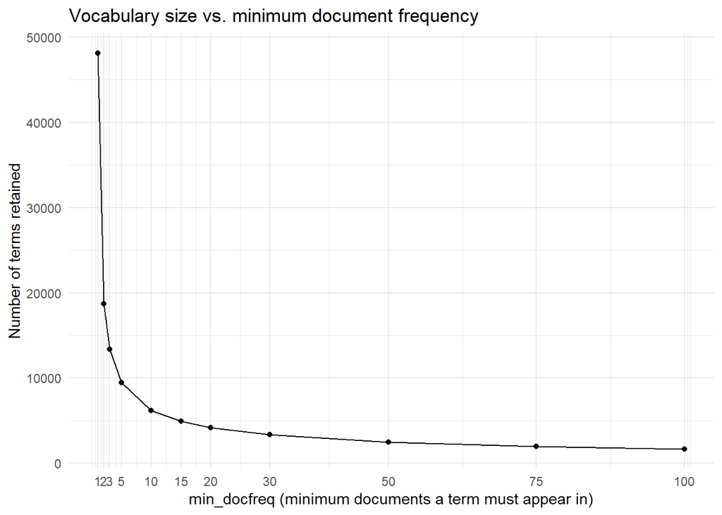

```r
# Build DFM on full corpus to explore vocabulary size vs. min_docfreq threshold
# Use this plot to choose min_docfreq in the fold loop below
dfm_full <- preprocess_tfidf(abstracts$text)

vocab_diag <- map_dfr(c(1, 2, 3, 5, 10, 15, 20, 30, 50, 75, 100), ~ tibble(
  min_docfreq  = .x,
  n_terms      = nfeat(dfm_trim(dfm_full, min_docfreq = .x)),
  pct_retained = nfeat(dfm_trim(dfm_full, min_docfreq = .x)) / nfeat(dfm_full) * 100
))

ggplot(vocab_diag, aes(x = min_docfreq, y = n_terms)) +
  geom_line() +
  geom_point() +
  scale_x_continuous(breaks = c(1, 2, 3, 5, 10, 15, 20, 30, 50, 75, 100)) +
  labs(title = "Vocabulary size vs. minimum document frequency",
       x     = "min_docfreq (minimum documents a term must appear in)",
       y     = "Number of terms retained") +
  theme_minimal()
```

```r
#print(vocab_diag)
```

```r
# Inspect terms that would be dropped at a given threshold
# Adjust `inspect_threshold` to match whichever cutoff you are considering
# Two-column table: terms dropped at min_df = 5 vs min_df = 10
doc_freqs <- docfreq(dfm_full)

term_frequency <- data.frame('n_documents' = doc_freqs) %>%
    rownames_to_column('term') %>%
    arrange(n_documents)

write.csv(term_frequency, here("04_output", "term_frequency.csv"), row.names = FALSE)

dropped_5  <- tibble(term = names(doc_freqs), docfreq = as.integer(doc_freqs)) %>%
  filter(docfreq < 5) %>%
  arrange(desc(docfreq)) %>%
  slice_head(n = 50) %>%
  pull(term)

dropped_10 <- tibble(term = names(doc_freqs), docfreq = as.integer(doc_freqs)) %>%
  filter(docfreq >= 5 & docfreq < 10) %>%
  arrange(desc(docfreq)) %>%
  slice_head(n = 50) %>%
  pull(term)

tibble(
  `Dropped at min_df = 5`  = dropped_5,
  `Dropped at min_df = 10 (additional)` = dropped_10
)
```

| Dropped at min_df = 5 | Dropped at min_df = 10 (additional) |
| --- | --- |
| aacap | mdr1 |
| ama | liber |
| atp-bind | remodel |
| curabl | low-frequ |
| maharashtra | street-involv |
| post-train | ancestri |
| indiana | non-aborigin |
| bdd | lectur |
| pallidi | angl |
| n2 | interrat |

[output cut: 40 more lines]

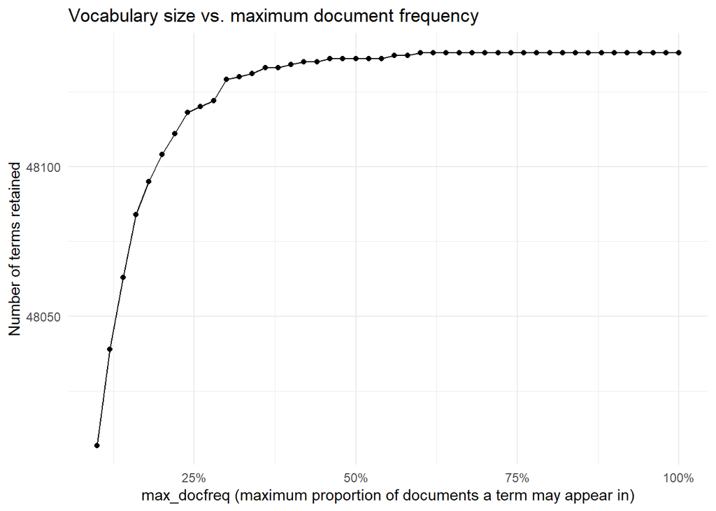

```r
# Max_df elbow plot: vocabulary retained as high-frequency terms are removed
max_df_diag <- map_dfr(
    seq(.1,1, by = .02),
  ~ tibble(
    max_docfreq_pct = .x,
    n_terms = nfeat(dfm_trim(dfm_full, max_docfreq = .x, docfreq_type = "prop"))
  )
)

ggplot(max_df_diag, aes(x = max_docfreq_pct, y = n_terms)) +
  geom_line() +
  geom_point() +
  scale_x_continuous(labels = scales::percent) +
  labs(title = "Vocabulary size vs. maximum document frequency",
       x     = "max_docfreq (maximum proportion of documents a term may appear in)",
       y     = "Number of terms retained") +
  theme_minimal()
```

```r
# Two-column table: terms dropped at two max_df thresholds (update cutoffs after viewing plot)
max_thresh_1 <- 0.30  # placeholder: update after viewing elbow plot
max_thresh_2 <- 0.20  # placeholder: update after viewing elbow plot

prop_freqs <- docfreq(dfm_full) / ndoc(dfm_full)

term_props <- data.frame('prop'= prop_freqs) %>%
    rownames_to_column('term') %>%
    inner_join(term_frequency, by = c('term')) %>%
    arrange(-prop)


dropped_max_1 <- names(prop_freqs[prop_freqs > max_thresh_1]) %>%
  head(50)

dropped_max_2 <- names(prop_freqs[prop_freqs > max_thresh_2 & prop_freqs <= max_thresh_1]) %>%
  head(50)

# Pad to equal length if needed
max_len <- max(length(dropped_max_1), length(dropped_max_2))
length(dropped_max_1) <- max_len
length(dropped_max_2) <- max_len

tibble(
  `Dropped at max_df = 30%` := dropped_max_1,
  `Dropped at max_df = 20%` := dropped_max_2
)
```

| Dropped at max_df = 30% | Dropped at max_df = 20% |
| --- | --- |
| use | adolesc |
| patient | report |
| drug | health |
| treatment | medic |
| disord | children |
| associ | may |
| studi | among |
| effect | group |
| result | includ |
| NA | signific |

[output cut: 15 more lines]

The scree plot shows the cumulative proportion of variance in the TF-IDF matrix explained by each successive SVD component, computed from a single fit on the full corpus outside the fold loop. Each component captures the next largest direction of variation in the document-term space; the singular values `svd_fit$d` are proportional to the amount of variance explained, and squaring them gives the variance contribution per dimension. The plot is used to inform the choice of `n_components`: an elbow in the curve indicates that additional components contribute diminishing returns. Note that for heterogeneous text corpora, this curve is often gradual with no sharp elbow, reflecting the fact that variance is spread across many latent topics rather than concentrated in a few dominant dimensions. In that case, `n_components` can be treated as a hyperparameter and evaluated empirically in `model_comparison.qmd`.

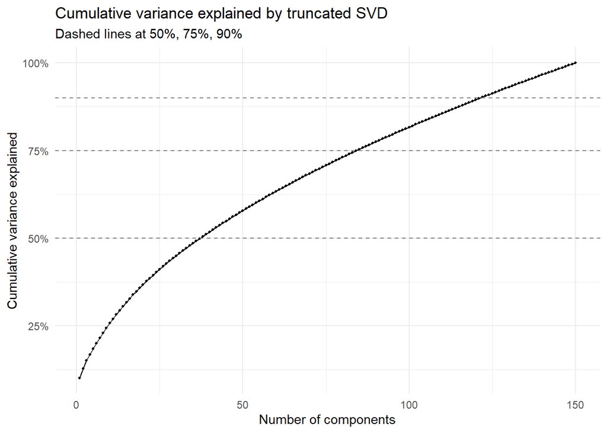

```r
# Fit SVD on the full training corpus (outside the fold loop) just for diagnostics
# Using larger nv than planning to keep so you can see where it level
dfm_diag <- preprocess_tfidf(abstracts$text) %>%
  dfm_trim(min_docfreq = 5)

idf_diag    <- docfreq(dfm_diag, scheme = "inverse", base = 10)
tfidf_diag  <- dfm_weight(dfm_diag, weights = idf_diag)
mat_diag    <- as(tfidf_diag, "sparseMatrix")

svd_diag <- irlba(mat_diag, nv = 150, center = FALSE, scale = FALSE)

# Proportion of variance explained by each component
var_explained <- svd_diag$d^2 / sum(svd_diag$d^2)
cumvar        <- cumsum(var_explained)

tibble(component = seq_along(var_explained),
       var       = var_explained,
       cumvar    = cumvar) %>%
  ggplot(aes(x = component)) +
  geom_line(aes(y = cumvar)) +
  geom_point(aes(y = cumvar), size = 0.8) +
  geom_hline(yintercept = c(0.50, 0.75, 0.90), linetype = "dashed", colour = "grey50") +
  scale_y_continuous(labels = scales::percent) +
  labs(title    = "Cumulative variance explained by truncated SVD",
       subtitle = "Dashed lines at 50%, 75%, 90%",
       x        = "Number of components",
       y        = "Cumulative variance explained") +
  theme_minimal()
```

The 2D scatter plot projects all documents onto the first two SVD dimensions and colors points by screening label, providing a direct visual assessment of whether the latent space separates included from excluded records. The first two dimensions are the directions of greatest variance in the training corpus and are not guaranteed to be the most discriminating for the classification task; visible separation here is a positive signal but its absence does not rule out useful structure in higher dimensions. Because included records are a small minority of the corpus, overplotting among the excluded class is expected — the key pattern to look for is whether included records cluster directionally or occupy a distinct region rather than being uniformly scattered among excluded records.

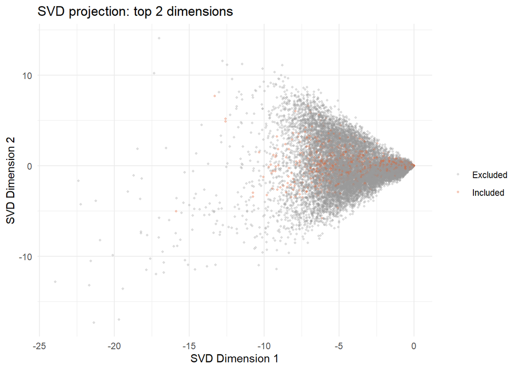

```r
# ---- 2D scatter plot ----
# Projects all documents onto the first two SVD dimensions, coloured by label.
# as.matrix() is applied to the small output matrix (n_docs x 2), not the
# large input -- this is safe and necessary to coerce from dgeMatrix.
proj_2d <- as.matrix(mat_diag %*% svd_diag$v[, 1:2]) %>%
  as.data.frame() %>%
  setNames(c("dim1", "dim2")) %>%
  mutate(label = factor(abstracts$outcome,
                        levels = c(0, 1),
                        labels = c("Excluded", "Included")))

ggplot(proj_2d, aes(x = dim1, y = dim2, colour = label)) +
  geom_point(alpha = 0.3, size = 0.8) +
  scale_colour_manual(values = c("Excluded" = "grey60", "Included" = "#E05C2A")) +
  labs(title  = "SVD projection: top 2 dimensions",
       x      = "SVD Dimension 1",
       y      = "SVD Dimension 2",
       colour = NULL) +
  theme_minimal()
```

The density plot displays the distribution of document scores along the single SVD dimension that most separates the two classes, identified by computing the absolute difference in class means across all retained dimensions and selecting the largest. Unlike the scatter plot, which is restricted to the top two variance dimensions, this plot specifically targets the dimension most relevant to the classification task and therefore gives a more direct assessment of whether the SVD representation captures signal useful for screening. Well-separated density curves indicate that the SVD space encodes meaningful differences between included and excluded abstracts along at least one dimension; heavy overlap suggests the representation may not carry strong discriminative signal for this task regardless of how many components are retained.

```r
# ---- Density plot ----
# Identifies the single SVD dimension that most separates the two classes
# by computing the absolute difference in class means across all retained
# dimensions. Plots density curves for included vs excluded along that dimension.
proj_full <- as.matrix(mat_diag %*% svd_diag$v) %>%
  as.data.frame() %>%
  mutate(label = abstracts$outcome)

mean_diffs <- proj_full %>%
  group_by(label) %>%
  summarise(across(starts_with("V"), mean)) %>%
  summarise(across(starts_with("V"), ~ abs(diff(.)))) %>%
  pivot_longer(everything(), names_to = "dim", values_to = "mean_diff") %>%
  arrange(desc(mean_diff))

best_dim <- mean_diffs$dim[1]
cat("Most discriminating dimension:", best_dim, "\n")
```

```
Most discriminating dimension: V8
```

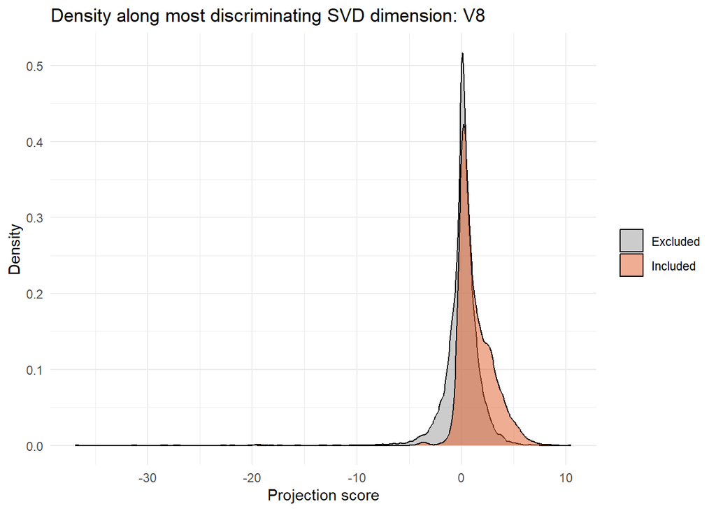

```r
proj_full %>%
  mutate(label = factor(label, levels = c(0, 1),
                        labels = c("Excluded", "Included"))) %>%
  ggplot(aes(x = .data[[best_dim]], fill = label)) +
  geom_density(alpha = 0.5) +
  scale_fill_manual(values = c("Excluded" = "grey60", "Included" = "#E05C2A")) +
  labs(title = paste("Density along most discriminating SVD dimension:", best_dim),
       x     = "Projection score",
       y     = "Density",
       fill  = NULL) +
  theme_minimal()
```

```r
# Number of latent dimensions to retain.
# 150 components selected based on scree plot inspection --
# captures over 90% of corpus variance for this collection.
# Can be treated as a tunable hyperparameter in model_comparison.qmd.
n_components <- 150

# List to collect test-fold SVD projections in row order
svd_test_list <- vector("list", 5)

for (fold_index in 1:5) {
  cat(sprintf("\n== TF-IDF + SVD Fold %d ==\n", fold_index))

  # test_idx:  the ~20% of records held out this iteration
  # train_idx: the remaining ~80% used to fit everything
  #
  # fold_index=1: test=fold1, train=folds2+3+4+5
  # fold_index=2: test=fold2, train=folds1+3+4+5
  # fold_index=3: test=fold3, train=folds1+2+4+5
  # fold_index=4: test=fold4, train=folds1+2+3+5
  # fold_index=5: test=fold5, train=folds1+2+3+4

  test_idx  <- folds[[fold_index]]
  train_idx <- setdiff(seq_len(nrow(abstracts)), test_idx)

  df_train <- abstracts[train_idx, ]
  df_test  <- abstracts[test_idx, ]

  # Compute min_docfreq proportion from training fold only
  min_doc_prop <- term_props %>%
    filter(n_documents <= 5) %>%
    pull(prop) %>%
    max()



  # Step 1: Build TF-IDF matrices using training-fold vocabulary and IDF weights.
  # dfm_match() aligns the test matrix to the training column layout:
  #   - drops test words absent from the training vocabulary (no loading in V)
  #   - inserts zero-columns for training words absent from the test fold
  # After this, both matrices have identical columns in identical order,
  # which is required for the SVD projection in Step 3 to be valid.
  dfm_train <- preprocess_tfidf(df_train$text) %>%
    dfm_trim(min_docfreq = min_doc_prop,
             max_docfreq = 0.25,
             docfreq_type = "prop")

  dfm_test <- preprocess_tfidf(df_test$text) %>%
    dfm_match(features = featnames(dfm_train))

  idf_train       <- docfreq(dfm_train, scheme = "inverse", base = 10)
  dfm_train_tfidf <- dfm_weight(dfm_train, weights = idf_train)
  dfm_test_tfidf  <- dfm_weight(dfm_test,  weights = idf_train)  # training IDF on test

  # Convert to sparse matrices -- irlba handles sparse input natively.
  # as.matrix() is intentionally avoided here; the full term matrix is too
  # large to densify (~70k terms). Only the small output projections are dense.
  mat_train <- as(dfm_train_tfidf, "sparseMatrix")
  mat_test  <- as(dfm_test_tfidf,  "sparseMatrix")

  # Step 2: Fit truncated SVD on the TRAINING fold only.
  # irlba() returns u (document scores), d (singular values), v (term loadings).
  # v encodes what each latent dimension means in terms of original terms.
  # It is estimated from training data only and never updated after this point.
  svd_fit <- irlba(mat_train, nv = n_components, center = FALSE, scale = FALSE)

  # Step 3: Project the TEST fold using FROZEN term loadings (v).
  # mat_test columns are aligned to mat_train columns by dfm_match() above,
  # so each column multiplies against the correct term loading in v.
  # Test documents have no influence on what the latent dimensions represent.
  test_proj <- as.matrix(mat_test %*% svd_fit$v)  # shape: n_test x n_components

  # Store test-fold projections with metadata
  svd_test_list[[fold_index]] <- as.data.frame(test_proj) %>%
    setNames(paste0("svd_", seq_len(n_components))) %>%
    mutate(id   = df_test$id,
           outcome = df_test$outcome,
           .before = 1)
}

# Assemble full-dataset SVD matrix, sorted by index
svd_full <- bind_rows(svd_test_list) %>%
  arrange(id)

saveRDS(svd_full, file = here('04_output', 'tfidf_svd_features.rds'))

write_csv(svd_full, here('04_output', 'tfidf_svd_features.csv'))
```

## Method 3: Doc2Vec

Doc2Vec is a neural network-based text representation that learns dense, low-dimensional numeric vectors for each document by training on word co-occurrence patterns in the corpus. Documents with similar content are mapped to similar vectors. Unlike TF-IDF, Doc2Vec captures semantic relationships between words and produces compact, non-sparse representations.

Doc2Vec embeddings are computed using Python’s `gensim` library accessed from R via `reticulate`. To prevent data leakage, a separate model is trained on the training folds within each CV fold, and test-fold embeddings are inferred using frozen word weights from that fold’s model. Test-fold embeddings are assembled into a single full-dataset matrix after the fold loop.

Preprocessing steps applied before training:

- Lowercase
- Keep only alphanumeric characters and spaces
- Normalize whitespace

```r
# Doc2Vec preprocessing: lowercase + alphanumeric only + normalize whitespace
preprocess_doc2vec <- function(.data) {
  .data %>%
    mutate(text = str_to_lower(text),
           text = str_replace_all(text, "[^a-z0-9]", " "),
           text = str_squish(text))
}
```

```r
# Import gensim Doc2Vec via reticulate
# Requires gensim in the active Python environment:
#   py_install("gensim")  # run once if not installed
TaggedDocument <- import("gensim.models.doc2vec")$TaggedDocument
Doc2Vec        <- import("gensim.models.doc2vec")$Doc2Vec

# Define a Python batch inference function to avoid crossing the R-Python
# boundary once per document (which causes C stack overflow at scale)
py_run_string("
def batch_infer(model, texts):
    # Return list of lists (not numpy array) -- reticulate converts reliably
    return [model.infer_vector(t.split()).tolist() for t in texts]
")
```

```r
# List to collect test-fold embeddings in row order
doc2vec_test_list <- vector("list", 5)

for (fold_index in 1:5) {
  cat(sprintf("\n== Doc2Vec Fold %d ==\n", fold_index))

  test_idx  <- folds[[fold_index]]
  train_idx <- setdiff(seq_len(nrow(abstracts)), test_idx)

  df_train <- abstracts[train_idx, ] %>% preprocess_doc2vec()
  df_test  <- abstracts[test_idx,  ] %>% preprocess_doc2vec()

  # Build tagged training documents for gensim
  # Each document: words = token list, tags = unique doc id string
  tagged_train <- lapply(seq_len(nrow(df_train)), function(i) {
    TaggedDocument(
      words = strsplit(df_train$text[i], " ")[[1]],
      tags  = list(as.character(df_train$id[i]))
    )
  })

  # Train Doc2Vec on training fold only
  model <- Doc2Vec(
    tagged_train,
    vector_size = 100L,
    window      = 5L,
    min_count   = 2L,
    epochs      = 5L,
    workers     = 4L,
    seed        = 42L
  )

  # Infer embeddings for test fold -- entire loop runs in Python to avoid
  # repeated R-Python boundary crossings that cause C stack overflow
  # batch_infer returns a list of 100-element lists; rbind assembles into matrix
  test_embeddings <- do.call(rbind, py$batch_infer(model, df_test$text))

  # Store with metadata -- row order matches df_test
  doc2vec_test_list[[fold_index]] <- as.data.frame(test_embeddings) %>%
      mutate(id       = df_test$id,
             outcome = df_test$outcome,
             .before     = 1)
}

# Assemble full-dataset Doc2Vec matrix, sorted by id
doc2vec_full <- bind_rows(doc2vec_test_list) %>%
    arrange(id)

write_csv(doc2vec_full, here('04_output', 'doc2vec_features.csv'))

saveRDS(doc2vec_full, file = here('04_output', 'doc2vec_features.rds'))
```

## Outputs

[output not shown]

## Key Implementation Notes

### 1. **Data Leakage Prevention**

- TF-IDF: Vocabulary and IDF weights learned from training fold only; `dfm_match()` aligns test vocabulary to training vocabulary; `docfreq()` extracts training IDF applied to test fold via `dfm_weight()`
- Doc2Vec: Model trained on training fold only; `infer_vector()` (gensim via reticulate) infers test embeddings with frozen word weights from that fold’s model
- PubMedBERT: Pre-trained, no leakage risk; all records encoded at once

### 2. **Preprocessing Differences**

- **TF-IDF**: Aggressive (lowercase, remove punctuation/numbers/symbols, stop words, stemming) – needed for sparse bag-of-words representations
- **Doc2Vec**: Light (lowercase, alphanumeric only, normalize whitespace) – model learns from word context and does not require aggressive cleaning
- **PubMedBERT**: None – pre-trained model handles tokenization and normalization internally

### 3. **Doc2Vec Implementation Note**

gensim’s `Doc2Vec` is called via `reticulate`. Test embeddings are inferred in a single Python batch call (`batch_infer`) to avoid repeated R-Python boundary crossings that cause C stack overflow at scale.

### 4. **Dimension Reduction**

#### Options for Discussion

The full TF-IDF matrix is approximately 1.6GB, which presents practical challenges for compute time during modeling, particularly for SVM and Random Forest across 5-fold CV. Options under consideration:

- **min_docfreq trimming**: (already implemented): removes rare terms appearing in fewer than N documents
- **max_docfreq trimming**: (already impletmented) removes terms appearing in a very high proportion of documents (domain-specific stop words with low discriminating value); threshold to be selected based on elbow plot
- **Information gain feature selection**: ranks terms by how much they reduce uncertainty about the class label; keeps top K terms most associated with the outcome; may capture signal that frequency-based trimming misses
- **Truncated SVD (LSA-Latent Semantic Analysis)**: compresses the matrix into a smaller set of dense components; standard approach for sparse TF-IDF matrices; fit on training fold only to prevent leakage; reduces columns from tens of thousands to 100-300
- Frequency trimming and SVD can be combined: trim first, then apply SVD to the reduced matrix